# Directed Acyclic Graphs (DAGs) in R

Kenta Okuyama, MPH, PhD

March 30, 2026

## Agenda (45 min)

- Introduction of DAGs (5 min)
  - Why DAGs
  - Key terms
- Build a DAG in R (25 min)
  - Study example - Workplace physical and social factors on low back pain (Tamekuni et al. 2026)
- Q&A (15 min)

## Introduction of DAGs

Why DAGs - it helps you:

- make causal assumptions explicit
- identify confounders
- decide what to (and what not to) adjust for
- communicate analysis decisions transparently

(Greenland, Pearl, and Robins 1999; Shrier and Platt 2008; Hernán and Robins 2020)

## Key terms - confounder

- Common cause of exposure and outcome

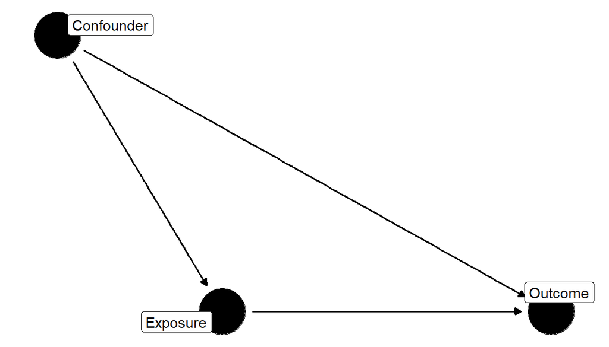

## Key terms - mediator

- Lies on the causal pathway between exposure and outcome

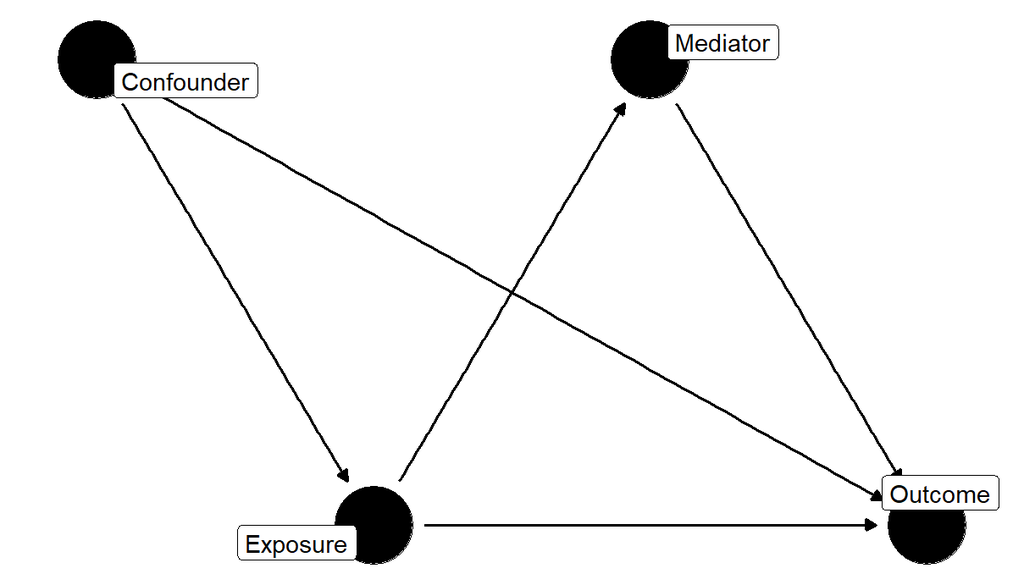

## Key terms - collider

- Common effect of two variables

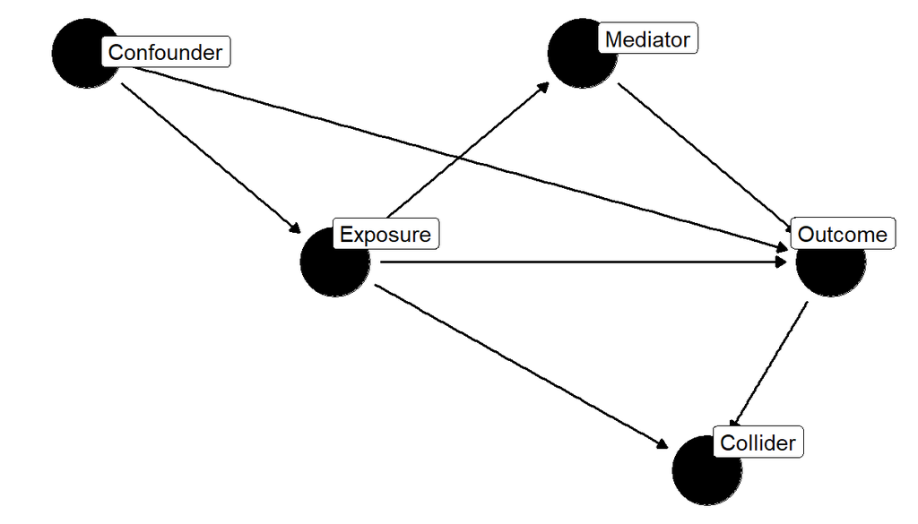

## Key terms - effect modifier

- Modify the effect of exposure on outcome *Standard DAGs do not directly encode effect modification (Attia, Holliday, and Oldmeadow 2022)

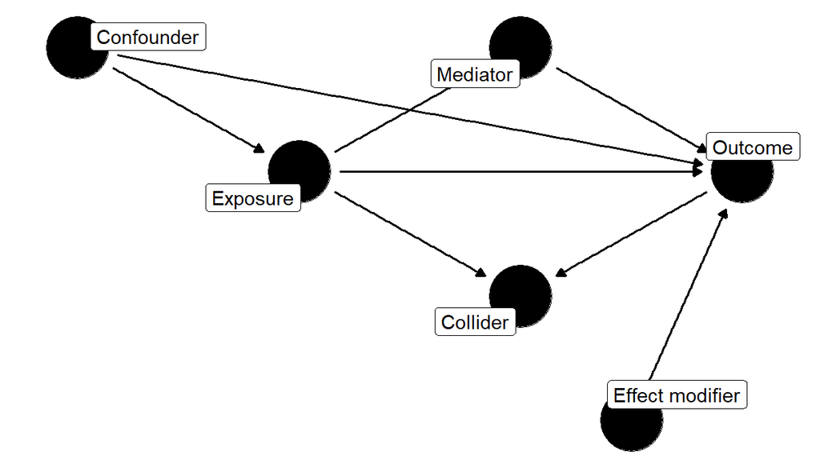

## Adjustment rules (for total effect)

- adjust confounders
- avoid adjusting mediators
- avoid adjusting/conditioning on colliders

(Greenland, Pearl, and Robins 1999; Hernán and Robins 2020)

## Why “adjust for confounders”?

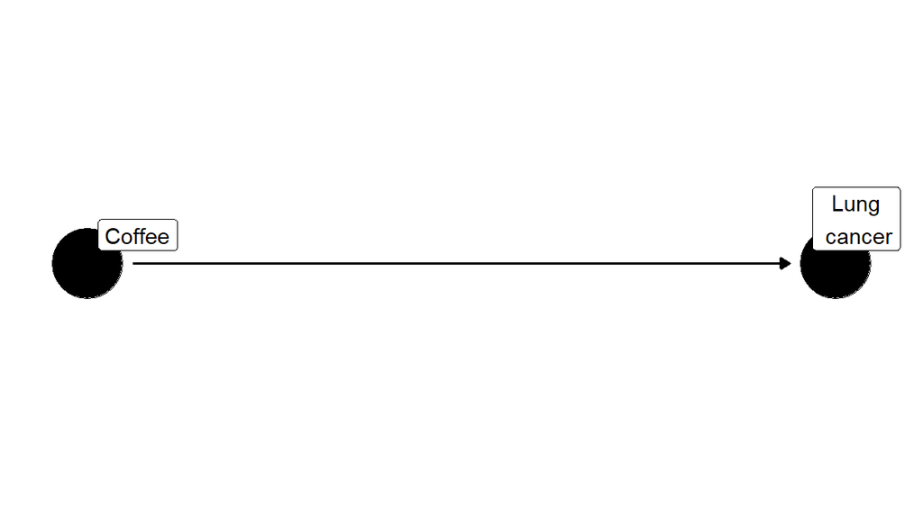

## Why “adjust for confounders”?

- Back door path: Coffee ← Smoking → Lung cancer

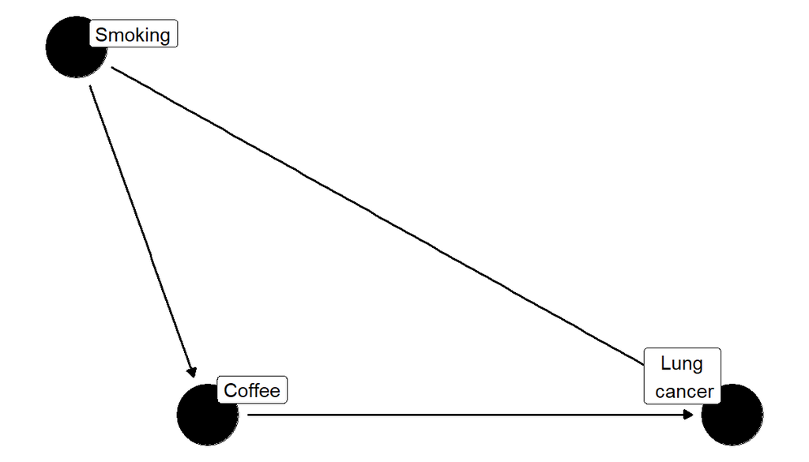

## Why “adjust for confounders”?

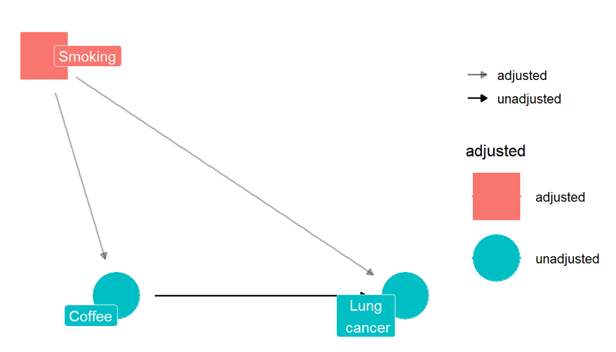

## Why not “adjust for mediators”?

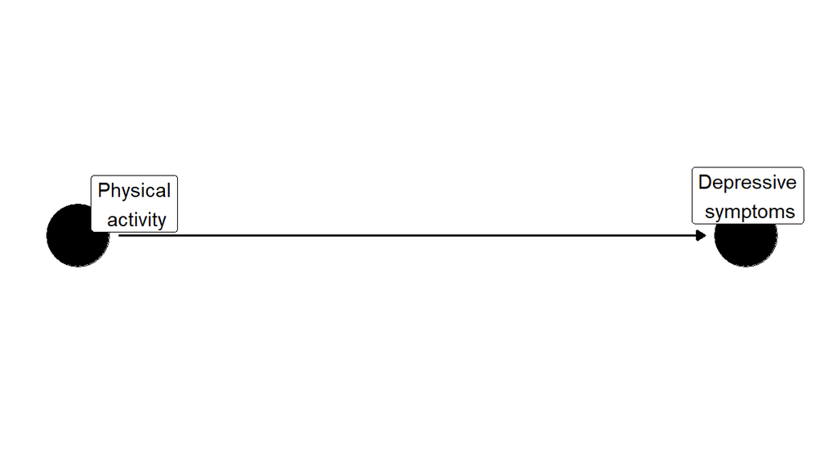

## Why not “adjust for mediators”?

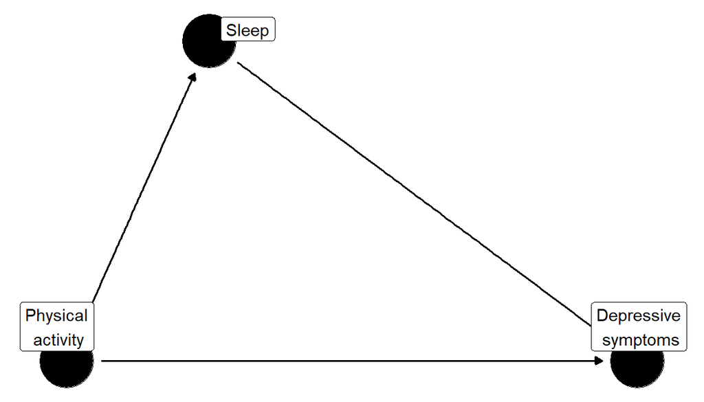

## Why not “adjust for mediators”?

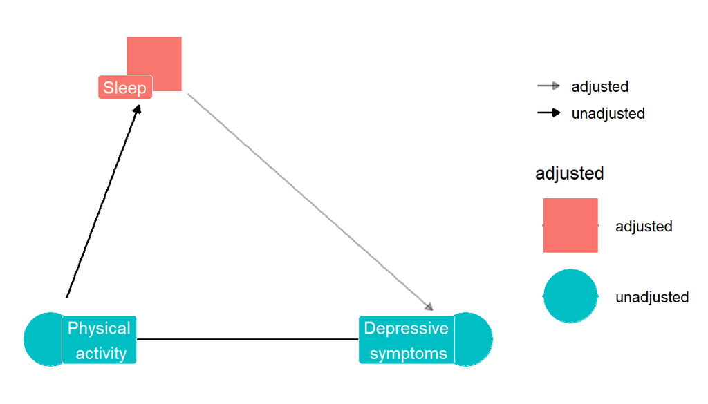

## Why not “adjust for colliders”?

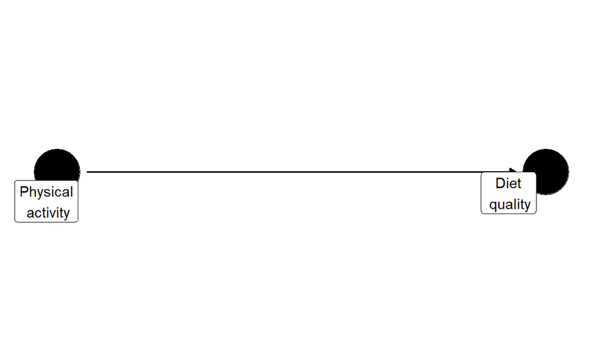

## Why not “adjust for colliders”?

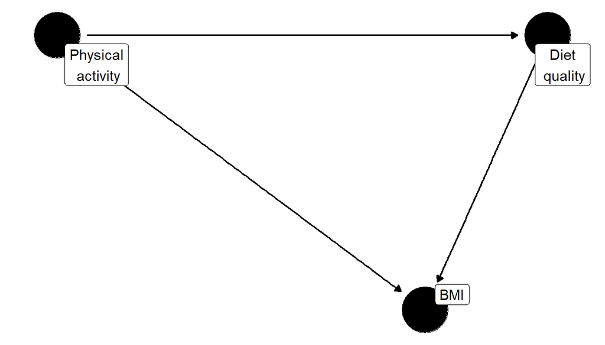

## Why not “adjust for colliders”?

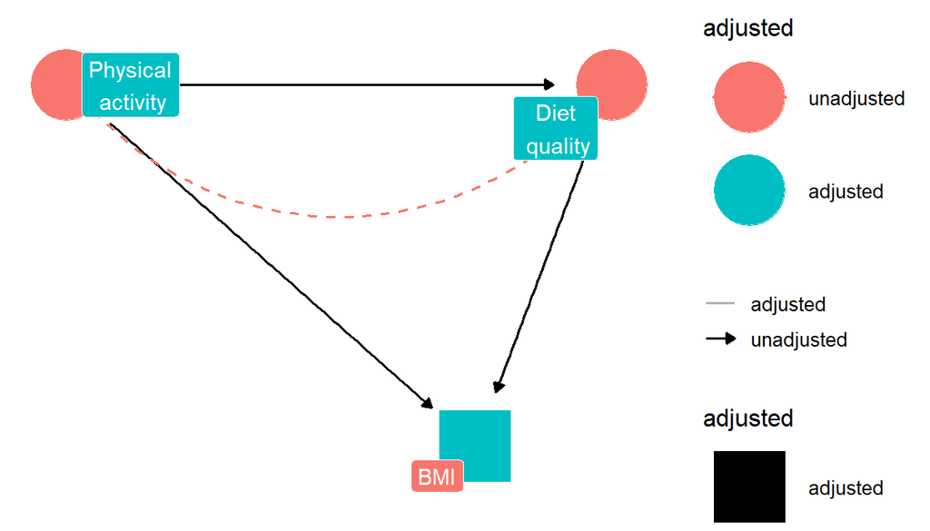

## Building a DAG

Study example:

- Cross-sectional survey-based study in Japan
- Workers at small/medium sized enterprises (n=762)
- Workplace physical and social factors → Low back pain

*The contents are partly modified for educational purposes (Tamekuni et al. 2026)

## Background and hypothesis

- High physical load (physical factor) → Low back pain
- Good interpersonal relations (social factor) may mitigate the association
- Previous studies investigated biopsychosocial factors on low back pain without causal structure

## Variables

- Physical load - low/high (exposure)
- Low back pain - yes/no (outcome)
- Age, Gender, Education, Smoking, Drinking, Body mass index (BMI), Job satisfaction, Depression, Interpersonal relations stress (confounders/mediators/effect modifiers)

## Start with exposure → outcome

```r
library(ggdag)
# 1. Position variables in x-y coordinates (physical load = p_load, low back pain = lbp)
coords1 <- list(
  x = c(p_load = 1, lbp = 3),
  y = c(p_load = 0, lbp = 0)
)

# 2. Define casual structures
g1 <- dagify(
  lbp ~ p_load,

  # set position of variables
  coords = coords1,

  # label variables
  labels = c(
    "lbp" = "LB pain",
    "p_load" = "Physical\n load"
    ),

  # define exposure and outcome
  exposure = "p_load",
  outcome = "lbp"
)
```

## DAG 1

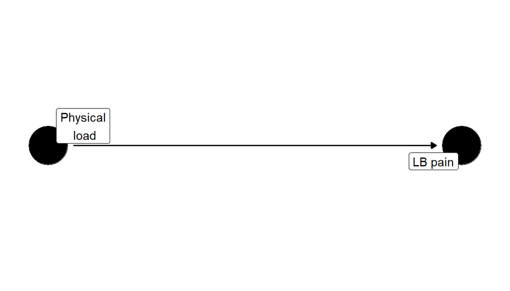

```r
ggdag(g1, text = FALSE, use_labels = "label") +
  theme_dag()
```

## Add socio-demographic factors

```r
# 1. Position variables in x-y coordinates
coords2 <- list(
  x = c(age = -2.5, gender = -2.5, education = -2, income = -2,
        p_load = 1, lbp = 3),
  y = c(age = -0.25, gender = -1, education = 0.5, income = 1,
        p_load = 0, lbp = 0)
)

# 2. Define casual structures
g2 <- dagify(
  lbp ~ p_load + age + gender + education + income,
  p_load ~ age + gender + education,
  education ~ gender,
  income ~ age + gender + education,
  coords = coords2,
  labels = c(
    "lbp" = "LB pain",
    "p_load" = "Physical\n load",
    "age" = "Age",
    "gender" = "Gender",
    "education" = "Education",
    "income" = "Income"
  ),
  exposure = "p_load",
  outcome = "lbp"
)
```

## DAG 2

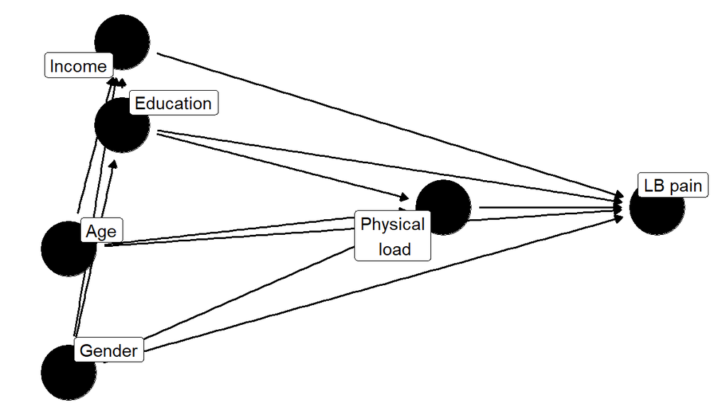

```r
ggdag(g2, text = FALSE, use_labels = "label") +
  theme_dag()
```

## Important points

- Start with a pen and paper
- Draw DAGs based on your subjective expertise
- Elaborate on DAGs through discussions with multi-disciplinary experts

## Add lifestyle factors

```r
# 1. Position variables in x-y coordinates
coords3 <- list(
  x = c(age = -2.5, gender = -2.5, education = -2, income = -2,
        drink = -1, smoke = -1, sleep = -0.5, pa = -1,
        p_load = 1, lbp = 3),
  y = c(age = -0.25, gender = -1, education = 0.5, income = 1,
        drink = 1, smoke = 0.5, sleep = -0.5, pa = -1,
        p_load = 0, lbp = 0)
)

# 2. Define causal structures
g3 <- dagify(
  lbp ~ p_load + age + gender + education + income + drink + smoke + sleep + pa,
  p_load ~ age + gender + education,
  education ~ gender,
  income ~ age + gender + education,
  drink ~ age + gender + education + income,
  smoke ~ age + gender + education + income,
  sleep ~  age + gender + education + income + drink + smoke + pa,
  pa ~ age + gender + education + income,

  coords = coords3,
  labels = c(
    "lbp" = "LB pain",
    "p_load" = "Physical\n load",
    "age" = "Age",
    "gender" = "Gender",
    "education" = "Education",
    "drink" = "Drinking",
    "smoke" = "Smoking",
    "sleep" = "Sleep\n quality",
    "pa" = "Physical\n activity",
    "income" = "Income"
  ),
  exposure = "p_load",
  outcome = "lbp"
)
```

## DAG 3

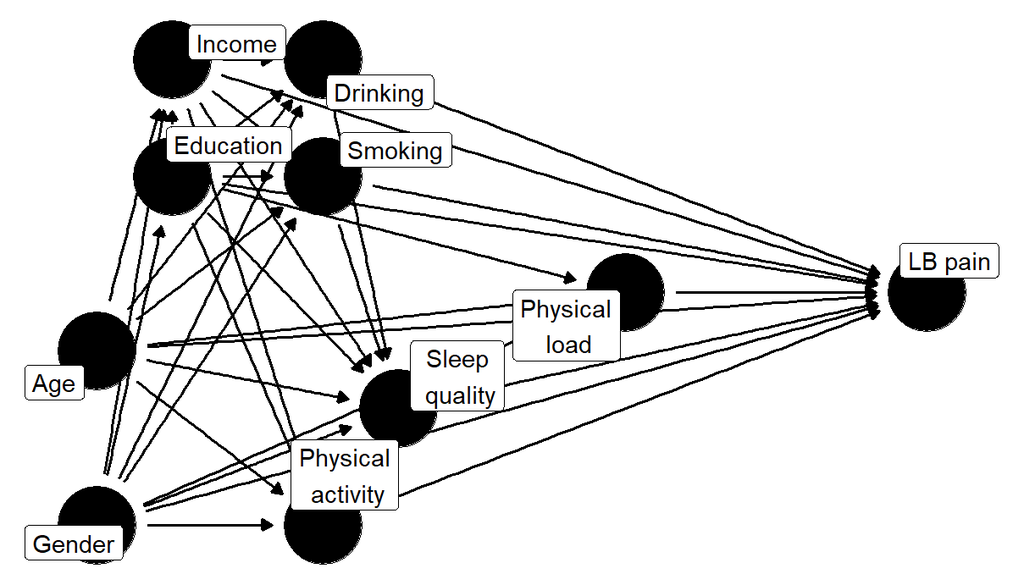

```r
ggdag(g3, text = FALSE, use_labels = "label") +
  theme_dag()
```

## Add the remaining variables

```r
# 1. Position variables in x-y coordinates
coords4 <- list(
  x = c(age = -2.5, gender = -2, education = -2, income = -2,
        drink = -1, smoke = -1, sleep = -0.5, pa = -1,
        bmi = 0, job_sat = 2, depress = 2, int_stress = 1,
        p_load = 1, lbp = 3),
  y = c(age = -0.25, gender = -1, education = 0.5, income = 1,
        drink = 1, smoke = 0.5, sleep = -0.5, pa = -1,
        bmi = -1.25, job_sat = -1, depress = 1, int_stress = -0.75,
        p_load = 0, lbp = 0)
)

# 2. Define causal structures
g4 <- dagify(
  lbp ~ p_load + age + gender + education + income + drink + smoke + sleep + pa + bmi + job_sat + depress + int_stress,
  p_load ~ age + gender + education,
  education ~ gender,
  income ~ age + gender + education,
  drink ~ age + gender + education + income,
  smoke ~ age + gender + education + income,
  sleep ~  age + gender + education + income + drink + smoke + pa,
  pa ~ age + gender + education + income,
  bmi ~ age + gender + education + income + drink + smoke + sleep + pa,
  job_sat ~ p_load + int_stress,
  depress ~ p_load + int_stress,
  int_stress ~ age + gender + education,

  coords = coords4,
  labels = c(
    "lbp" = "LB pain",
    "p_load" = "Physical\n load",
    "age" = "Age",
    "gender" = "Gender",
    "education" = "Education",
    "drink" = "Drinking",
    "smoke" = "Smoking",
    "sleep" = "Sleep\n quality",
    "pa" = "Physical\n activity",
    "income" = "Income",
    "bmi" = "BMI",
    "job_sat" = "Job\n satisfaction",
    "depress" = "Depression",
    "int_stress" = "Interpersonal\n stress"
  ),
  exposure = "p_load",
  outcome = "lbp"

)
```

## DAG 4

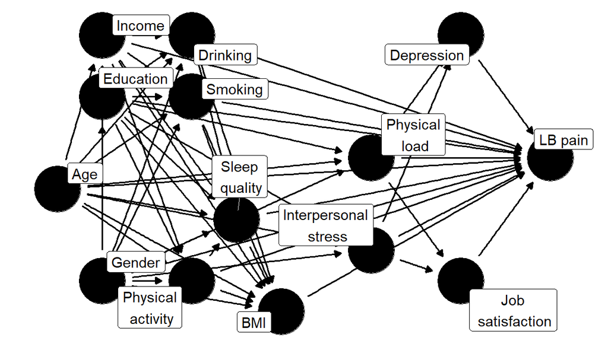

```r
ggdag(g4, text = FALSE, use_labels = "label") +
  theme_dag()
```

## Identifying an adjustment set

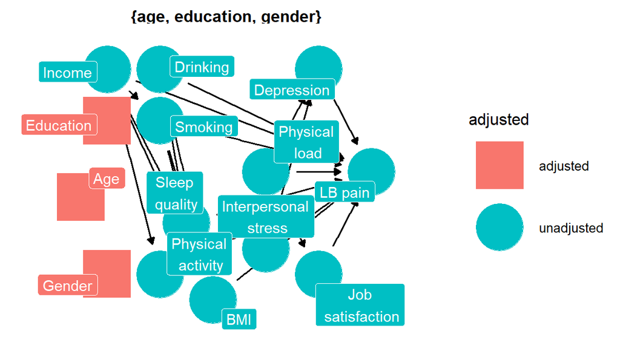

```r
ggdag_adjustment_set(g4, text = FALSE, use_labels = "label") +
  theme_dag()
```

## Add unmeasured variables

```r
# 1. Position variables in x-y coordinates
coords5 <- list(
  x = c(
    prev_behav = -3.2,
    age = -2.5, gender = -2, education = -2, income = -2,
    drink = -1, smoke = -1, sleep = -0.5, pa = -1,
    bmi = 0, job_sat = 2, depress = 2, int_stress = 1,
    p_load = 1, lbp = 3
  ),
  y = c(
    prev_behav = -1.8,
    age = -0.25, gender = -1, education = 0.5, income = 1,
    drink = 1, smoke = 0.5, sleep = -0.5, pa = -1,
    bmi = -1.25, job_sat = -1, depress = 1, int_stress = -0.75,
    p_load = 0, lbp = 0
  )
)

# 2. Define causal structures
g5 <- dagify(
  lbp ~ p_load + age + gender + education + income + drink + smoke + sleep + pa + bmi + job_sat + depress + int_stress,
  p_load ~ age + gender + education + drink + smoke + bmi,
  education ~ gender,
  income ~ age + gender + education,
  drink ~ age + gender + education + income + prev_behav,
  smoke ~ age + gender + education + income + prev_behav,
  sleep ~ age + gender + education + income + drink + smoke + pa,
  pa ~ age + gender + education + income + prev_behav,
  bmi ~ age + gender + education + income + drink + smoke + sleep + pa + prev_behav,
  job_sat ~ p_load + int_stress,
  depress ~ p_load + int_stress,
  int_stress ~ age + gender + education,

  coords = coords5,
  labels = c(
    "prev_behav" = "U: Previous\n health behaviour",
    "lbp" = "LB pain",
    "p_load" = "Physical\nload",
    "age" = "Age",
    "gender" = "Gender",
    "education" = "Education",
    "drink" = "Drinking",
    "smoke" = "Smoking",
    "sleep" = "Sleep\nquality",
    "pa" = "Physical\nactivity",
    "income" = "Income",
    "bmi" = "BMI",
    "job_sat" = "Job\nsatisfaction",
    "depress" = "Depression",
    "int_stress" = "Interpersonal\nstress"
  ),
  exposure = "p_load",
  outcome = "lbp",
  latent = "prev_behav"
)
```

## DAG 5

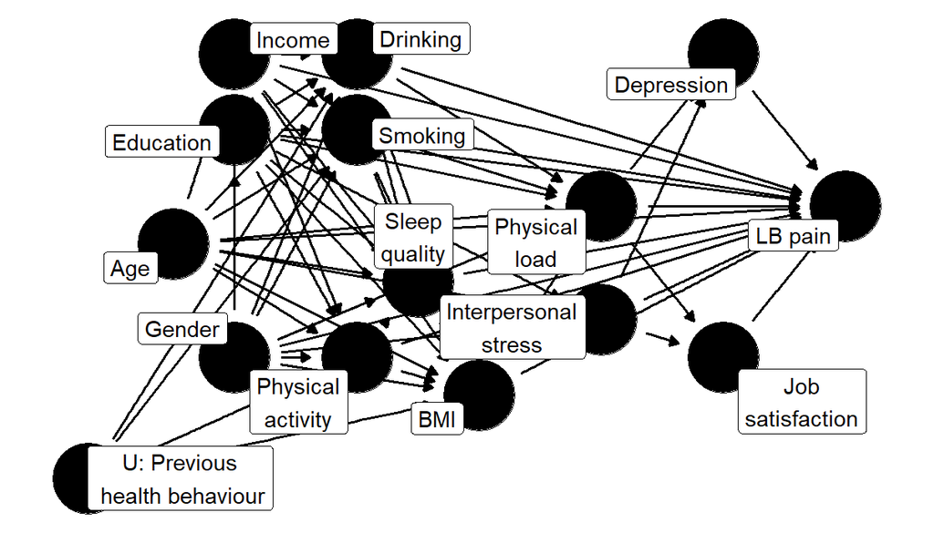

```r
ggdag(g5, text = FALSE, use_labels = "label") +
  theme_dag()
```

## Identifying an adjustment set

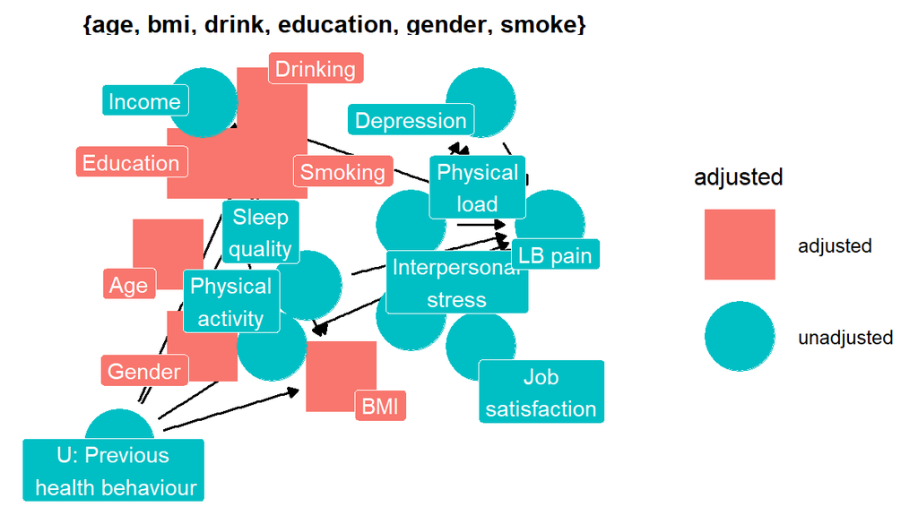

```r
ggdag_adjustment_set(g5, text = FALSE, use_labels = "label") +
  theme_dag()
```

## What about time-varying variables in longitudinal studies?

Time-indexed DAGs

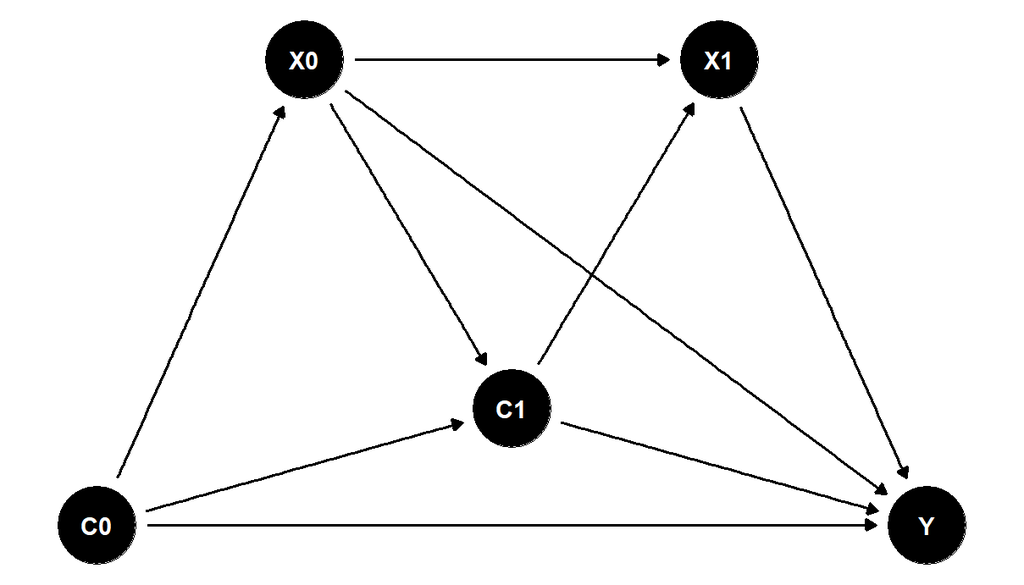

## Take-home points

- DAGs make causal assumptions explicit and improve adjustment decisions
- Separate confounders vs mediators vs colliders to avoid bias
- Build DAGs based on your subjective expertise
- Use advanced DAGs to encode effect modification/interaction
- Use time-indexed DAGs for longitudinal studies

## Slides and codes

Slides and codes:

https://github.com/okuyamak/dag-seminar

Follow us:

https://www.linkedin.com/company/nextgen-health-research-bridge

## References

Attia, John, Elizabeth Holliday, and Christopher Oldmeadow. 2022. “A Proposal for Capturing Interaction and Effect Modification Using DAGs.” *International Journal of Epidemiology* 51 (4): 1047–53.

Greenland, Sander, Judea Pearl, and James M. Robins. 1999. “Causal Diagrams for Epidemiologic Research.” *Epidemiology* 10 (1): 37–48. https://doi.org/10.1097/00001648-199901000-00008.

Hernán, Miguel A., and James M. Robins. 2020. *Causal Inference: What If*. Boca Raton: Chapman & Hall/CRC.

Shrier, Ian, and Robert W. Platt. 2008. “Reducing Bias Through Directed Acyclic Graphs.” *BMC Medical Research Methodology* 8: 70. https://doi.org/10.1186/1471-2288-8-70.

Tamekuni, Yurika, Kenta Okuyama, Atsushi Motohiro, Daijo Shiratsuchi, et al. 2026. “Physical and Social Factors Differentiating Acute and Chronic Low Back Pain Among Small- and Medium-Sized Enterprise Workers in Japan: A Cross-Sectional Study.” *European Journal of Investigation in Health, Psychology and Education* 16 (2): 17. https://doi.org/10.3390/ejihpe16020017.